# R Notebook

### F-06 III: Big Boxplot №2 (category = |L2FC| > 4 & padj < 0.01)

```r
grDevices::png(filename = "bx_big3.png",  width = 16.5, height = 10, units = 'cm', res = 400)

bx_big3 <- data_bigbx3 %>%
  ggplot(mapping = aes(x = as.factor(start), y = unqC_Sum)) +
  geom_boxplot() +
  geom_boxplot(data = high_boxplots3, aes(x = as.factor(start), y = unqC_Sum, fill = gene_ID, color = gene_ID),
               show.legend = FALSE) +
  geom_point(data = data_bigbx3 %>% filter(qtl_pos == 1), aes(x = as.factor(start), y = 10000), shape = 15,
             size = 2.5, color = "#00A86B", fill = "#00A86B") +
  annotate("label", label = "QTL region", y = 11000, x = "14635146", size = 3) +
  #geom_rect(aes(xmin= as.factor("12875963"), xmax= as.factor("16344528"), ymin=0, ymax=Inf), alpha = 0.5) +
  #geom_segment(aes(x = "12875963", y = 0, xend = "12875963", yend = 17500)) +
  #scale_x_discrete(labels = levels(factor(data_bigbx1$gene_ID))) +
  scale_x_discrete(labels = levels(factor(data_bigbx3$gene_ID)),
                   guide = guide_axis(check.overlap = TRUE)
  ) +
  scale_fill_manual(values = colors) +
  scale_color_manual(values = colors) +
  ggrepel::geom_label_repel(data = gene_names3, aes(x = as.factor(start), y = max, label = gene_ID, fill = gene_ID),
                            hjust = -0.2,
                            show.legend = FALSE) +
  labs(y = "Total Gene expression") +
  theme_bw() +
  theme(
    #panel.grid.major = element_line(colour = 'grey85', size = 0.2),
    #panel.grid.minor = element_line(colour = 'grey90', size = 0.1),
    axis.title.x = element_blank(),
    axis.title.y = element_text(size = 10),
    #axis.title.y = element_blank(),
    plot.title = element_text(size = 10),
    axis.text.x = element_text(angle = 45, hjust=1),
    #legend.position = c(0.8,0.2), #You can adjust legend position here
    legend.background = element_rect(color = "black")
  )

bx_big3

dev.off()
```

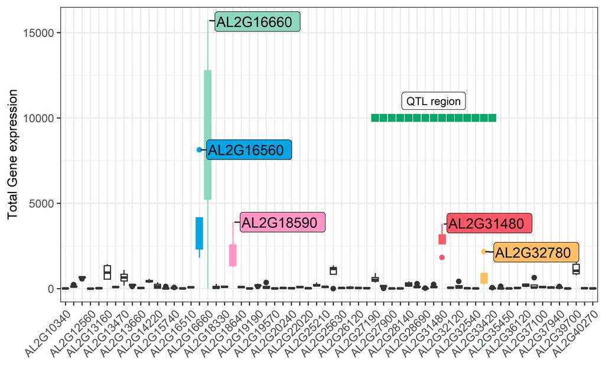

```r
knitr::include_graphics("bx_big3.png")
```

# Part G: Test QTL region

## Step G-01: Compare QTL region with 3 other regions

### G-01 I: Make a column for regions

```r
result.withRegions <- result.withGeneMap.asDF %>%
  mutate(region = case_when(
    start <  12875963/2 ~ "1",
    start <  12875963 ~ "2",
    start <  16344528 ~ "QTL",
    TRUE ~ "3"))
```

### G-01 II: Compare results by significance groups (from “Upper”/“Lower”/“Non-sig” categoies)

We treat gene as having significant difference if it is not from “Non-sig” category

Variables: * num_sig = 1 if gene expression difference is significant, 0 - otherwise * n - number of genes in the region * mean total - average gene expression (mean unqC_total) * sum_num_sig - number of significant genes in the region * perc_sig - percent of significant genes from the overall number of genes in the region

```r
resultsRegionsCat <- result.withRegions %>%
  mutate(num_sig = ifelse(Significance == "non-Sig",0,1)) %>%
  group_by(region) %>%
  summarise(n = n(),
            mean_total = mean(unqC_total),
            sum_num_sig = sum(num_sig)) %>%
    mutate(perc_sig = sum_num_sig/n)

resultsRegionsCat
```

```
## # A tibble: 4 x 5
##   region     n mean_total sum_num_sig perc_sig
##   <chr>  <int>      <dbl>       <dbl>    <dbl>
## 1 1        449      4079.          51   0.114
## 2 2        276      3682.          36   0.130
## 3 3        516      3693.          33   0.0640
## 4 QTL      520      3912.          47   0.0904
```

### G-01 III: Compare results by significance groups (depend only on adjusted p-value)

We treat gene as having significant difference if its adjusted p-value < 0.001

```r
resultsRegionsPadj <- result.withRegions %>%
  mutate(num_sig = ifelse(padj < 0.001 ,1,0)) %>%
  group_by(region) %>%
  summarise(n = n(),
            mean_total = mean(unqC_total),
            sum_num_sig = sum(num_sig)) %>%
  mutate(perc_sig = sum_num_sig/n)

resultsRegionsPadj
```

```
## # A tibble: 4 x 5
##   region     n mean_total sum_num_sig perc_sig
##   <chr>  <int>      <dbl>       <dbl>    <dbl>
## 1 1        449      4079.          56    0.125
## 2 2        276      3682.          31    0.112
## 3 3        516      3693.          53    0.103
## 4 QTL      520      3912.          56    0.108
```

### G-01 IV: Run Chi-squared tests

Tests compare whether proportions in sample differ.

All the analysis checks the proportions of significant genes obtained by adjusted p-value (< 0.001)

```r
check_prop <- resultsRegionsPadj$perc_sig[4] #Exected proportion

chisq.test(c(56, 449-56), p = c(check_prop, 1-check_prop))$p.value #Region 1
```

```
## [1] 0.2444053
```

```r
chisq.test(c(31, 276-31), p = c(check_prop, 1-check_prop))$p.value #Region 2
```

```
## [1] 0.8041747
```

```r
chisq.test(c(53, 516-53), p = c(check_prop, 1-check_prop))$p.value #Region 3
```

```
## [1] 0.7152144
```

There is no case when Chisq test p-value is less than 0.05. Hence, we cannot reject the null hypothesis about the 0 difference.

## Step G-02: Compare QTL region with random samples of equal size

### G-02 I: Get the data outside of the QTL region as a separate dataframe

```r
resultsOutQTL <- result.withRegions %>% filter(region != "QTL") %>%
  mutate(num_sig = ifelse(padj < 0.001, 1, 0))
```

### G-02 II: Run Chisq test for 10000 random samples

Random samples from this part do not take into account actual genomic positions. For each iteration of the loop random genes are taken to form a dataset. Then the proportion if significant genes is calculated and checked whether it significantly differs from the expected proportions (which is an actual proportion which we obtained for the QTL region).

Then we calculate a share of samples with significantly different proportions of significant genes.

#### Run the loop

```r
# Prepare dataframe to take loop records.
df_test<- as.data.frame(matrix(nrow = 10000, ncol = 3))
df_test <- df_test %>%
  dplyr::rename(num_sig = V1,
         prop = V2,
         p.value = V3)

set.seed(256)

for (i in 1:10000) {
  df_i <- resultsOutQTL[sample(nrow(resultsOutQTL), 520), ]
  n_sig <- sum(df_i$num_sig == 1)
  n_unsig <- sum(df_i$num_sig == 0)
  df_test$num_sig[i] <- n_sig
  df_test$prop[i] <- n_sig/nrow(df_i)
  df_test$p.value[i] <- chisq.test(c(n_sig, n_unsig), p = c(check_prop, 1 - check_prop))$p.value
}
```

#### Get the share of sample where proportion of significant genes differs from the QTL region

```r
sum(df_test$p.value < 0.05)/10000
```

```
## [1] 0.0253
```

#### Check regions with significant difference in proportions whether this proportion was larger or smaller

1 - proportion of significant genes in QTL region is larger than in random sample 0 - otherwise

```r
df_test_sig <- df_test %>% filter(p.value < 0.05) %>%
  mutate(compare = ifelse(prop < check_prop, 1, 0))

df_test_sig %>% group_by(compare) %>%
  summarise(n =n())
```

```
## # A tibble: 2 x 2
##   compare     n
##     <dbl> <int>
## 1       0   236
## 2       1    17
```

Result: we can see that even if there was a signigicant difference in the proportion of significant genes, in most of the cases this proportion was larger than in QTL region.

### G-02 III: Histogram of obtained proportions

```r
grDevices::png(filename = "chi_hist.png",  width = 12.5, height = 8, units = 'cm', res = 400)

chi_hist <- df_test %>%
  ggplot(aes(x = prop)) +
  geom_histogram(bins = 15, fill = "#58508d", alpha = 0.9) +
  geom_vline(xintercept = check_prop, color = "red", size = 1) +
  scale_x_continuous() +
  annotate("label", label = "Expected proportion\n0.108",
           x= 0.09 , y = 2000, size = 3) +
  annotate("segment", x = 0.099, y = 2000,
           xend = check_prop, yend = 2000,
           arrow = arrow(length = unit(0.1, "cm"), type = "closed"),
           lineend = "butt", linejoin = "mitre",
           size = 0.6) +
  theme_bw() +
  theme(
    panel.grid.major = element_line(colour = 'grey85', size = 0.2),
    panel.grid.minor = element_line(colour = 'grey90', size = 0.1),
    axis.title.x = element_blank(),
    axis.title.y = element_blank(),
    plot.title = element_blank(),
    axis.text.x = element_text(angle = 45, hjust=1),
    #legend.position = c(0.8,0.2), #You can adjust legend position here
    legend.background = element_rect(color = "black"),
    legend.title = element_text(size = 8),
    legend.text = element_text(size = 8)
  )

chi_hist

dev.off()
```

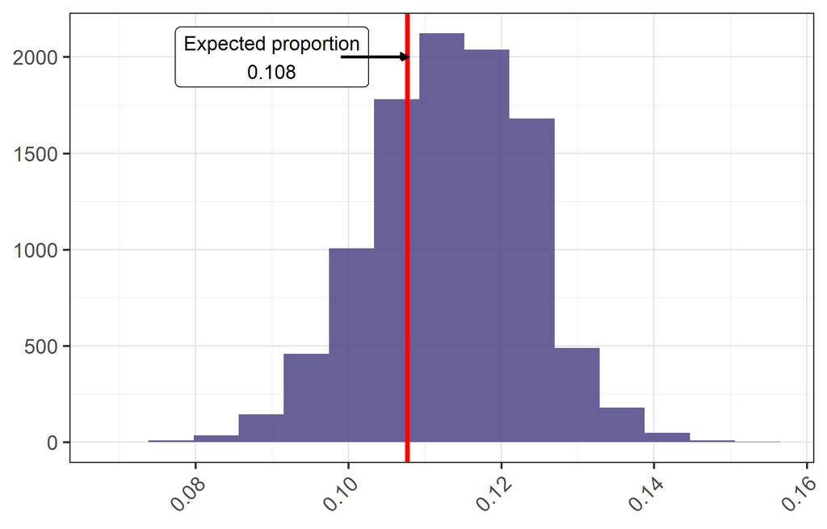

```r
knitr::include_graphics("chi_hist.png")
```

We can see that mostly the proportions of significant genes tend to be higher than proportion from the QTL region.

## Step G-03: Compare QTL region with samples of equal size ordered by genomic position

In this part we make samples of equal size which are go before the QTL region by genomic position. The region after the QTL has only 516 genes which were already check by the Chisq test. But we would like to know whether there is an interval of 520 genes which could have significantly different proportion of significant genes.

### G-03 I: Prepare a dataframe with genes outside of QTL regions arranged be genomic position

```r
# Arrange genes outside of qtl region by genomic position
resultsSortedOutQTL <- resultsOutQTL %>%
  arrange(start)

# Calculate the number of genes before the start of QTL region
check_rows <- sum(resultsSortedOutQTL$start < 12875963)
```

### G-03 II: Run Chisq test for all 520 gene size samples before QTL region

All in all there 206 samples of 520 genes before the QTL region.

#### Run the loop

```r
# Prepare a dataframe for loop records
df_test_2<- as.data.frame(matrix(nrow = check_rows - 520 + 1, ncol = 3))

df_test_2 <- df_test_2 %>%
  dplyr::rename(num_sig = V1,
                prop = V2,
                p.value = V3)

# Loop
for (i in 1:(check_rows-520+1)) {
  df_i2 <- resultsSortedOutQTL[i:(i+519),]
  n_sig2 <- sum(df_i2$num_sig == 1)
  n_unsig2 <- sum(df_i2$num_sig == 0)
  df_test_2$num_sig[i] <- n_sig2
  df_test_2$prop[i] <- n_sig2/nrow(df_i2)
  df_test_2$p.value[i] <- chisq.test(c(n_sig2, n_unsig2), p = c(check_prop, 1 - check_prop))$p.value
}
```

#### Get the share of samples where proportion of significant genes differs from the QTL region

```r
sum(df_test_2$p.value < 0.05)
```

```
## [1] 0
```

Result: there are no regions of equal size before the QTL regions which have significantly different number of significant genes.

### G-03 III: Histogram of obtained proportions

```r
grDevices::png(filename = "chi_hist_2.png",  width = 12.5, height = 8, units = 'cm', res = 400)

chi_hist_2 <- df_test_2 %>%
  ggplot(aes(x = prop)) +
  geom_histogram(#bins = 15,
                 fill = "#58508d", alpha = 0.9) +
  geom_vline(xintercept = check_prop, color = "red", size = 1) +
  scale_x_continuous(limits = c(0.085,0.13)) +
  annotate("label", label = "Expected proportion\n0.108",
           x= 0.0927 , y = 40, size = 3) +
  annotate("segment", x = 0.099, y = 40,
           xend = check_prop, yend = 40,
           arrow = arrow(length = unit(0.1, "cm"), type = "closed"),
           lineend = "butt", linejoin = "mitre",
           size = 0.6) +
  theme_bw() +
  theme(
    panel.grid.major = element_line(colour = 'grey85', size = 0.2),
    panel.grid.minor = element_line(colour = 'grey90', size = 0.1),
    axis.title.x = element_blank(),
    axis.title.y = element_blank(),
    plot.title = element_blank(),
    axis.text.x = element_text(angle = 45, hjust=1),
    #legend.position = c(0.8,0.2), #You can adjust legend position here
    legend.background = element_rect(color = "black"),
    legend.title = element_text(size = 8),
    legend.text = element_text(size = 8)
  )

chi_hist_2
dev.off()
```

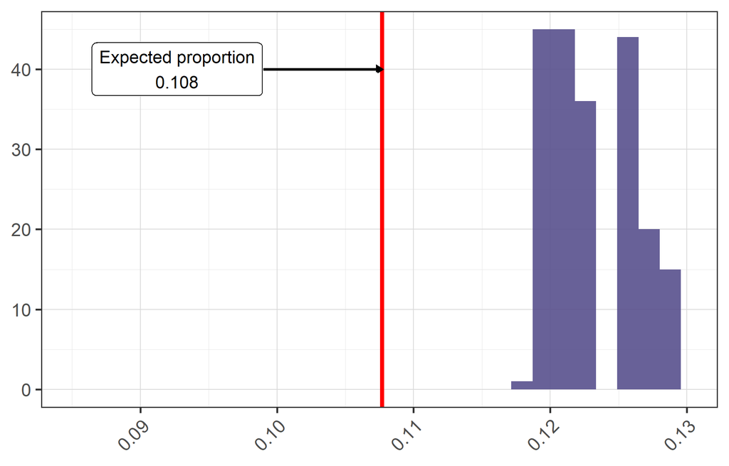

```r
knitr::include_graphics("chi_hist_2.png")
```

At the same time, we can cleaely see that in all cases the proportions of significant genes a higher, than that of QTL regions.

# Part H: Karyoplot

#### Upload useful packages

```r
library(karyoploteR)
library(Biostrings)
```

## Step H-01: Prepare data

#### Upload lyrata_genome

```r
lyr.chr <- fasta.index("lyrata_genome.fa") #%>% head(5)
typeof(lyr.chr)
```

```
## [1] "list"
```

#### select required rows and then add a mutant column

```r
lyr.chr <- lyr.chr %>%
  dplyr::select(desc, seqlength) %>%
  dplyr::mutate(chrom = base::strsplit(desc, " "))
```

#### Select columns

```r
# only select the first element of the mutant column
lyr.chr$chrom <- base::sapply(lyr.chr$chrom, `[`, 1)

# again select only required columns
lyr.chr <- lyr.chr %>%
  dplyr::select(chrom, seqlength)
```

#### replace the word “scaffold_” with null string

```r
lyr.chr <- data.frame(lapply(lyr.chr, function(x) {
  gsub("scaffold_", "", x)
}))
```

#### the values in chrom are stored as factor -> convert it into character and numeric

```r
lyr.chr$chrom <- as.numeric(as.character(lyr.chr$chrom))
lyr.chr$seqlength <- as.numeric(as.character(lyr.chr$seqlength))
```

```r
lyr.chr <- lyr.chr %>%
  filter(as.numeric(chrom) < 9) %>%
  arrange(chrom)
```

#### add prefix to the chromosome number

```r
lyr.chr$chrom <- base::paste0("chr", lyr.chr$chrom)
```

## Step H-02: Plot the choromosome using karyoploteR

#### Create custom GenomeRanges for lyrata

```r
lyr.custom.genome <- toGRanges(data.frame(
  chr = c(lyr.chr$chrom), start = rep(1, length(lyr.chr$chrom)),
  end = c(lyr.chr$seqlength)
))
lyr.custom.genome
```

```
## GRanges object with 8 ranges and 0 metadata columns:
##     seqnames     ranges strand
##        <Rle>  <IRanges>  <Rle>
##   1     chr1 1-33132539      *
##   2     chr2 1-19320864      *
##   3     chr3 1-24464547      *
##   4     chr4 1-23328337      *
##   5     chr5 1-21221946      *
##   6     chr6 1-25113588      *
##   7     chr7 1-24649197      *
##   8     chr8 1-22951293      *
##   -------
##   seqinfo: 8 sequences from an unspecified genome; no seqlengths
```

#### prepare cytobands from GFF file - make GRanges of available trancription database

```r
gffRangedGenome.aly <- rtracklayer::import.gff("lyrata1.to9.Rawat.gff")
gffRangedGenome.aly %>% head(5)
```

```
## GRanges object with 5 ranges and 8 metadata columns:
##       seqnames    ranges strand |    source       type     score     phase
##          <Rle> <IRanges>  <Rle> |  <factor>   <factor> <numeric> <integer>
##   [1]     chr1    1-2541      - | version-2 gene            0.43      <NA>
##   [2]     chr1    1-2541      - | version-2 transcript      0.43      <NA>
##   [3]     chr1    62-144      - | version-2 intron          0.96      <NA>
##   [4]     chr1   253-406      - | version-2 intron          1.00      <NA>
##   [5]     chr1  783-1422      - | version-2 intron          1.00      <NA>
##                 ID        Name                Note          Parent
##        <character> <character>     <CharacterList> <CharacterList>
##   [1]    AL1G10010   AL1G10010 Protein_Coding_gene
##   [2] AL1G10010.t1        <NA>                           AL1G10010
##   [3] AL1G10010.t1        <NA>                           AL1G10010
##   [4] AL1G10010.t1        <NA>                           AL1G10010
##   [5] AL1G10010.t1        <NA>                           AL1G10010
##   -------
##   seqinfo: 9 sequences from an unspecified genome; no seqlengths
```

#### creating cytobands

```r
aly.cytoBands <- as.data.frame(gffRangedGenome.aly) %>%
  dplyr::filter(type == "gene") %>%
  dplyr::select(seqnames, start, end, strand, width, Name)

  # convert cytobands to GRanges object
aly.cytoBands <- toGRanges(aly.cytoBands)
```

#### plot custom genome

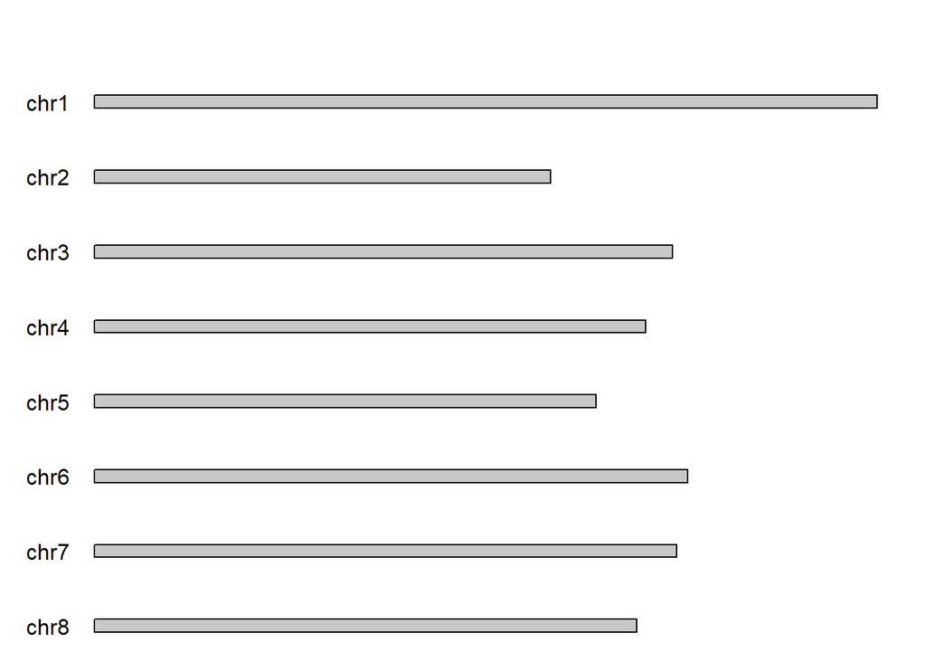

```r
kp.lyr <- plotKaryotype(genome = lyr.custom.genome)
```

```r
library(AnnotationDbi)
library(GenomicFeatures)
```

```r
txdb.aly <- makeTxDbFromGFF("lyrata1.to9.Rawat.gff", format = "gff",
                            dataSource = "Rawat et. al",
                            organism = "Arabidopsis lyrata")
```

```
## Import genomic features from the file as a GRanges object ... OK
## Prepare the 'metadata' data frame ... OK
## Make the TxDb object ...
```

[output not shown]

[output cut: 66 more lines]

[output not shown]

```
## OK
```

```r
txdb.aly
```

```
## TxDb object:
## # Db type: TxDb
## # Supporting package: GenomicFeatures
## # Data source: Rawat et. al
## # Organism: Arabidopsis lyrata
## # Taxonomy ID: 59689
## # miRBase build ID: NA
## # Genome: NA
## # Nb of transcripts: 32868
## # Db created by: GenomicFeatures package from Bioconductor
## # Creation time: 2022-04-05 20:09:33 +0300 (Tue, 05 Apr 2022)
## # GenomicFeatures version at creation time: 1.42.3
## # RSQLite version at creation time: 2.2.10
## # DBSCHEMAVERSION: 1.2
```

```r
columns(txdb.aly)
```

```
##  [1] "CDSCHROM"   "CDSEND"     "CDSID"      "CDSNAME"    "CDSPHASE"
##  [6] "CDSSTART"   "CDSSTRAND"  "EXONCHROM"  "EXONEND"    "EXONID"
## [11] "EXONNAME"   "EXONRANK"   "EXONSTART"  "EXONSTRAND" "GENEID"
## [16] "TXCHROM"    "TXEND"      "TXID"       "TXNAME"     "TXSTART"
## [21] "TXSTRAND"   "TXTYPE"
```

```r
summary(txdb.aly)
```

```
## Length  Class   Mode
##      1   TxDb     S4
```

```r
metadata(txdb.aly)
```

```
##                                        name
## 1                                   Db type
## 2                        Supporting package
## 3                               Data source
## 4                                  Organism
## 5                               Taxonomy ID
## 6                          miRBase build ID
## 7                                    Genome
## 8                         Nb of transcripts
## 9                             Db created by
## 10                            Creation time
## 11 GenomicFeatures version at creation time
## 12         RSQLite version at creation time
## 13                          DBSCHEMAVERSION
##                                           value
## 1                                          TxDb
## 2                               GenomicFeatures
## 3                                  Rawat et. al
## 4                            Arabidopsis lyrata
## 5                                         59689
## 6                                          <NA>
## 7                                          <NA>
## 8                                         32868
## 9     GenomicFeatures package from Bioconductor
## 10 2022-04-05 20:09:33 +0300 (Tue, 05 Apr 2022)
## 11                                       1.42.3
## 12                                       2.2.10
## 13                                          1.2
```

```r
head(seqlevels(txdb.aly), 15)
```

```
## [1] "chr1" "chr2" "chr3" "chr4" "chr5" "chr6" "chr7" "chr8" "Chr9"
```

#### extract the GRanges by geneID

```r
genes.aly <- genes(txdb.aly)
genes.aly
```

```
## GRanges object with 30142 ranges and 1 metadata column:
##             seqnames          ranges strand |     gene_id
##                <Rle>       <IRanges>  <Rle> | <character>
##   AL1G10010     chr1          1-2541      - |   AL1G10010
##   AL1G10020     chr1       3306-6161      - |   AL1G10020
##   AL1G10040     chr1      9476-10535      + |   AL1G10040
##   AL1G10050     chr1     10548-11941      - |   AL1G10050
##   AL1G10060     chr1     12235-13421      - |   AL1G10060
##         ...      ...             ...    ... .         ...
##   AL9U12200     Chr9 1791630-1793287      + |   AL9U12200
##   AL9U12210     Chr9 1792941-1795545      - |   AL9U12210
##   AL9U12220     Chr9 1796870-1801565      - |   AL9U12220
##   AL9U12230     Chr9 1810180-1812874      + |   AL9U12230
##   AL9U12240     Chr9 1836100-1837535      - |   AL9U12240
##   -------
##   seqinfo: 9 sequences from an unspecified genome; no seqlengths
```

```r
head(genes.aly,15)
```

```
## GRanges object with 15 ranges and 1 metadata column:
##             seqnames      ranges strand |     gene_id
##                <Rle>   <IRanges>  <Rle> | <character>
##   AL1G10010     chr1      1-2541      - |   AL1G10010
##   AL1G10020     chr1   3306-6161      - |   AL1G10020
##   AL1G10040     chr1  9476-10535      + |   AL1G10040
##   AL1G10050     chr1 10548-11941      - |   AL1G10050
##   AL1G10060     chr1 12235-13421      - |   AL1G10060
##         ...      ...         ...    ... .         ...
##   AL1G10120     chr1 39834-42611      - |   AL1G10120
##   AL1G10130     chr1 42668-46181      - |   AL1G10130
##   AL1G10140     chr1 46346-48809      + |   AL1G10140
##   AL1G10160     chr1 49457-51261      - |   AL1G10160
##   AL1G10170     chr1 51346-52761      - |   AL1G10170
##   -------
##   seqinfo: 9 sequences from an unspecified genome; no seqlengths
```

```r
View(genes.aly)
```

#### make a copy

```r
result.withGeneID.asDF.withRowNames <- result.withGeneMap.asDF
```

#### select gene_ID as rowNames - this helps in merging the data

```r
rownames(result.withGeneID.asDF.withRowNames) <-
  result.withGeneID.asDF.withRowNames$gene_ID
```

#### Merge the data

```r
mcols(genes.aly) <- result.withGeneID.asDF.withRowNames[
  names(genes.aly),
  c("log2FoldChange", "stat", "pvalue", "padj",
    "gene_ID", "gene_Name", "Significance")]
```

#### Add more data

```r
genes.aly.ordered <- genes.aly[base::order(genes.aly$padj, na.last = TRUE), ]

filtered.genes.aly <- genes.aly[!is.na(genes.aly$padj)]
log.pval <- -log10(filtered.genes.aly$padj)
mcols(filtered.genes.aly)$log.pval <- log.pval

sign.genes <- filtered.genes.aly[filtered.genes.aly$padj < 0.05,]
interest.genes <- filtered.genes.aly[filtered.genes.aly$gene_Name %in% list("PIN1", "PIN3", "BRC2")]

top.genes <- genes.aly.ordered[1:6]

filtered.genes.aly[filtered.genes.aly$gene_Name == "BRC2"]
```

```
## GRanges object with 0 ranges and 8 metadata columns:
##    seqnames    ranges strand | log2FoldChange      stat    pvalue      padj
##       <Rle> <IRanges>  <Rle> |      <numeric> <numeric> <numeric> <numeric>
##        gene_ID   gene_Name Significance  log.pval
##    <character> <character>  <character> <numeric>
##   -------
##   seqinfo: 9 sequences from an unspecified genome; no seqlengths
```

```r
fc.ymax <- ceiling(max(abs(range(sign.genes$log2FoldChange))))
fc.ymin <- -fc.ymax

cex.val <- sqrt(sign.genes$log.pval)/3

points.top <- 0.8

# To color the dots
col.over <- "#E63946"
col.under <- "#457b92"

sign.col <- rep(col.over, length(sign.genes))
sign.col[sign.genes$log2FoldChange<0] <- col.under

gene.mean <- start(top.genes) + (end(top.genes) - start(top.genes))/2
```

## Step H-03: Plot Karyoplot

```r
grDevices::png(filename = "kp_lyr.png",  width = 16.5, height = 10, units = 'cm', res = 400)



# Base Karyoplot
kp.lyr <- plotKaryotype(
  genome= lyr.custom.genome, cytobands = aly.cytoBands,
  chromosomes = "chr2",
  plot.type=2)
# Add points
kp.lyr <- kpPoints(kp.lyr, data=sign.genes, y=sign.genes$log2FoldChange, cex=cex.val, ymax=fc.ymax, ymin=fc.ymin, col=sign.col,
         #r1=points.top)
)

# Add y-axis
kpAxis(kp.lyr, ymax=fc.ymax, ymin=fc.ymin,
       r1=points.top, cex = 0.8
)

# Add name of y label axis
kpAddLabels(kp.lyr, labels = "log2 Fold Change", srt=90, pos=1, label.margin = 0.07, ymax=fc.ymax, ymin=fc.ymin,
            r1=points.top, cex = 0.8
)
gene.mean <- start(top.genes) + (end(top.genes) - start(top.genes))/2


kpSegments(kp.lyr, chr=as.character(seqnames(top.genes)), x0=gene.mean, x1=gene.mean, y0=top.genes$log2FoldChange, y1=fc.ymax, ymax=fc.ymax, ymin=fc.ymin,
           r1=points.top
           )

# Text markers
kpPlotMarkers(kp.lyr, top.genes, labels = names(top.genes), text.orientation = "horizontal",
              r0=points.top, label.dist = 0.003, cex = 0.8
              )

kpPlotDensity(kp.lyr, data=filtered.genes.aly, window.size = 10e4, data.panel = 2,
                    r1 = 0.8)

kp.lyr
```

[output not shown]

[output cut: 521 more lines]

[output not shown]

```r
dev.off()
```

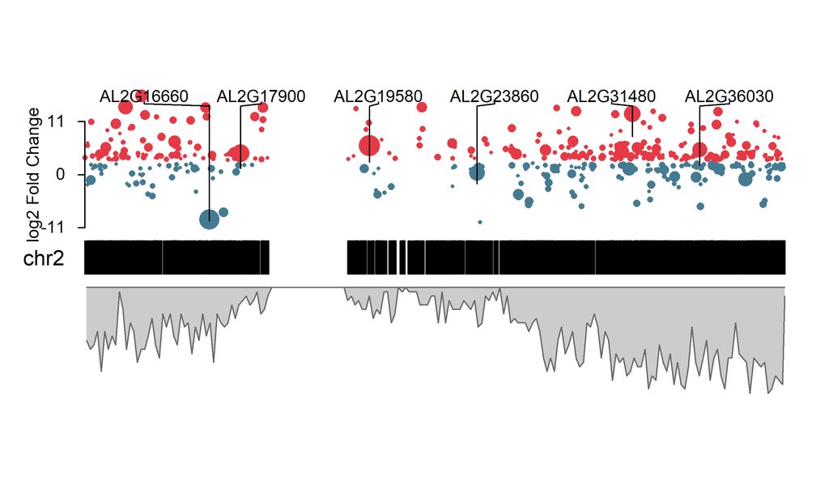

```r
knitr::include_graphics("kp_lyr.png")
```